# Validation: extract_tdt() under T-varying shape parameters

Author

Daniel W.A. Noble (with Claude)

Published

May 13, 2026

## Context

The default `fit_4pl()` in `bayesTLS` puts a `temp_c` slope on every 4PL sub-parameter (`lowraw`, `upraw`, `logk`, `mid`). When the truth has real temperature signal on $u$, $\ell$, or $k$, the resulting $\log_{10}\text{LT50}(T)$ curve is **bent rather than straight in $T$**. This breaks the constant-shape closed forms used in the classical TDT derivations (cf. Equation 7 of the manuscript).

The question this note answers: when the truth is bent, does `extract_tdt()` still return sensible $z$, $CT_{max_{1hr}}$, $T_{crit}$, and bent-curve posteriors? Or does the closed-form assumption inside the package introduce bias?

The answer is no, it doesn’t bias the answers — because `extract_tdt()` operates on the **fitted 4PL surface** rather than on closed-form expressions:

- $CT_{max_{1hr}}$ comes from `derive_temperature_for_duration()`, which inverts the surface at $t_\text{ref}$ per posterior draw. No closed form for the asymmetry correction is needed.
- $z$ comes from a per-draw OLS regression of $\log_{10}\text{LT50}$ on $T$ across the assay grid, where the per-draw $\log_{10}\text{LT50}(T)$ curve is itself recovered by `derive_ltx_curve()` (numerical inversion of the survival surface, again per draw). When the curve is straight, the OLS returns the closed-form $z$; when it’s bent, the OLS returns the **average local slope** across the assay grid.

This note runs a strong-truth simulation to demonstrate both points.

## Simulation truth (strong T effects)

```r
library(bayesTLS)
set.seed(123)

temps     <- c(30, 32, 34, 36, 38)
durations <- c(1, 5, 15, 45, 135, 405)
n_rep     <- 30
n_per_rep <- 30
phi       <- 5

true_params_ext <- list(
  ell_raw  = qlogis(0.05 / 0.49),
  u_raw_0  = qlogis((0.92 - 0.51) / 0.49),
  u_raw_T  = -0.60,   # strong decline in u with T
  log_k_0  = log(8),
  log_k_T  = 0.30,    # strong rise in k with T
  m_beta0  = 1.5,
  m_beta1  = -0.15,
  T_bar    = 34
)
```

True natural-scale parameters at each assay temperature, and the implied bent $\log_{10}\text{LT50}(T)$ curve:

```r
true_at_T <- function(T_value) {
  T_c <- T_value - true_params_ext$T_bar
  list(
    ell = 0.49 * plogis(true_params_ext$ell_raw),
    u   = 0.51 + 0.49 * plogis(true_params_ext$u_raw_0 +
                               true_params_ext$u_raw_T * T_c),
    k   = exp(true_params_ext$log_k_0 + true_params_ext$log_k_T * T_c),
    mid = true_params_ext$m_beta0 + true_params_ext$m_beta1 * T_c
  )
}

true_log10_LT50 <- function(T_value) {
  p <- true_at_T(T_value)
  p$mid + (1 / p$k) * log((p$u - 0.5) / (0.5 - p$ell))
}

true_local_z <- function(T_at, h = 0.5) {
  -1 / ((true_log10_LT50(T_at + h) -
         true_log10_LT50(T_at - h)) / (2 * h))
}

T_grid_truth   <- seq(20, 45, by = 0.001)
ll_grid_truth  <- vapply(T_grid_truth, true_log10_LT50, numeric(1))
true_CTmax_1hr <- T_grid_truth[which.min(abs(ll_grid_truth - log10(60)))]

truth_table <- tibble::tibble(
  T               = temps,
  u_true          = vapply(temps, function(T) true_at_T(T)$u, numeric(1)),
  k_true          = vapply(temps, function(T) true_at_T(T)$k, numeric(1)),
  log10_LT50_true = vapply(temps, true_log10_LT50, numeric(1)),
  local_z_true    = vapply(temps, true_local_z, numeric(1))
)
truth_table
```

```
# A tibble: 5 × 5
      T u_true k_true log10_LT50_true local_z_true
  <dbl>  <dbl>  <dbl>           <dbl>        <dbl>
1    30  0.991   2.41           2.14          6.05
2    32  0.973   4.39           1.81          6.22
3    34  0.92    8              1.49          6.27
4    36  0.807  14.6            1.17          6.34
5    38  0.666  26.6            0.862         6.53
```

```r
sprintf("Mean local z = %.3f °C; range = %.3f", mean(truth_table$local_z_true),
        max(truth_table$local_z_true) - min(truth_table$local_z_true))
```

```
[1] "Mean local z = 6.282 °C; range = 0.478"
```

```r
sprintf("True CTmax_1hr = %.3f °C", true_CTmax_1hr)
```

```
[1] "True CTmax_1hr = 32.206 °C"
```

The truth has $u$ declining from $\sim 0.99$ to $0.67$ across the assay range and $k$ rising from $2.4$ to $26.6$. The resulting local $z(T)$ varies from $6.05$ at $T=30$ to $6.53$ at $T=38$ — a 0.48 °C spread, clearly distinguishable from the constant-shape case (where local $z$ would be the same everywhere). The truth $CT_{max_{1hr}} \approx 32.2$ °C.

## Fit with the default `fit_4pl()`

```r
design <- tidyr::expand_grid(
  T   = temps, t = durations, rep = seq_len(n_rep)
) |>
  dplyr::mutate(log10_t = log10(t),
                T_c     = T - true_params_ext$T_bar,
                n       = n_per_rep)

sim_bb_ext <- design |>
  dplyr::mutate(
    ell    = 0.49 * plogis(true_params_ext$ell_raw),
    u      = 0.51 + 0.49 * plogis(true_params_ext$u_raw_0 +
                                  true_params_ext$u_raw_T * T_c),
    k      = exp(true_params_ext$log_k_0 + true_params_ext$log_k_T * T_c),
    mid    = true_params_ext$m_beta0 + true_params_ext$m_beta1 * T_c,
    p_true = ell + (u - ell) / (1 + exp(k * (log10_t - mid))),
    p_draw = rbeta(dplyr::n(), p_true * phi, (1 - p_true) * phi),
    y      = rbinom(dplyr::n(), size = n, prob = p_draw)
  )

std_ext <- standardize_data(sim_bb_ext,
                            temp = "T", duration = "t",
                            n_total = "n", n_surv = "y",
                            duration_unit = "minutes")
```

```r
models_dir <- here::here("output", "models")

wf_ext <- fit_4pl(std_ext,
                  chains = 4, iter = 2000, cores = 4, seed = 123,
                  file = file.path(models_dir,
                                   "sim_4pl_ext_betabin_DEFAULT_strong_v1"))
```

[output not shown]

[output cut: 43 more lines]

[output not shown]

## `extract_tdt()` vs analytical truth

```r
et_ext <- extract_tdt(wf_ext, t_ref = 60, time_multiplier = 1, ndraws = 1000)

et_ext$z$summary
```

```
# A tibble: 1 × 3
  z_median z_lower z_upper
     <dbl>   <dbl>   <dbl>
1     6.72    6.26    7.31
```

```r
et_ext$CTmax$summary
```

```
# A tibble: 1 × 4
  target_surv temp_lower temp_median temp_upper
        <dbl>      <dbl>       <dbl>      <dbl>
1         0.5       31.7        32.0       32.2
```

```r
et_ext$T_crit$summary
```

```
# A tibble: 1 × 5
  TC_rate_low TC_rate_high temp_lower temp_median temp_upper
        <dbl>        <dbl>      <dbl>       <dbl>      <dbl>
1         0.1            1       11.3        15.2       18.6
```

## Bent $\log_{10}\text{LT50}(T)$ curve recovered numerically

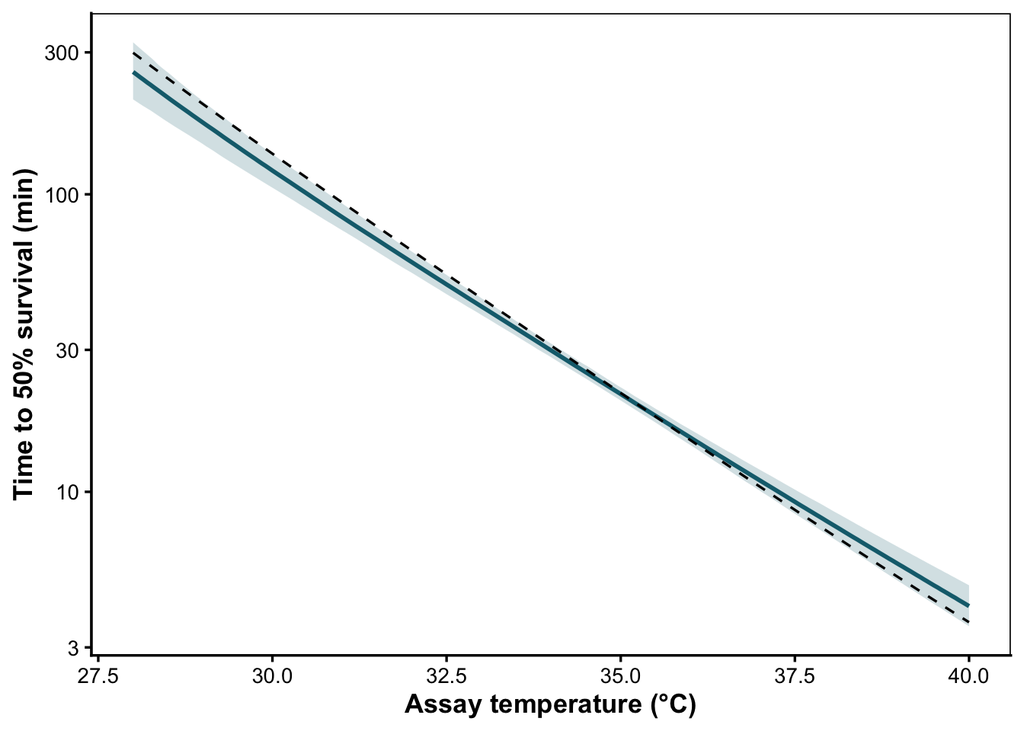

```r
truth_overlay <- {
  Ts <- seq(min(temps) - 2, max(temps) + 2, by = 0.05)
  tibble::tibble(temp = Ts,
                 duration_median = 10 ^ vapply(Ts, true_log10_LT50,
                                               numeric(1)))
}

plot_ltx_curve(et_ext$lt50_curve) +
  ggplot2::geom_line(data = truth_overlay,
                     ggplot2::aes(x = temp, y = duration_median),
                     linetype = "dashed", colour = "black",
                     inherit.aes = FALSE)
```

The posterior median (blue) tracks the analytical truth (dashed black) through the bend; the 95% CrI is wider at the edges of the assay range, as expected (the data only constrain the curve where there are observations).

## Local $z(T)$ recovery

```r
half_step <- 0.5
local_z_summary <- purrr::map_dfr(temps, function(T_at) {
  z_per_draw <- et_ext$lt50_curve$draws |>
    dplyr::group_by(.draw) |>
    dplyr::summarise(
      z_local = -1 / ((stats::approx(temp, log10(duration_out),
                                     xout = T_at + half_step)$y -
                       stats::approx(temp, log10(duration_out),
                                     xout = T_at - half_step)$y) /
                      (2 * half_step)),
      .groups = "drop"
    )
  q <- stats::quantile(z_per_draw$z_local, c(0.025, 0.5, 0.975),
                       na.rm = TRUE, names = FALSE)
  tibble::tibble(T_at = T_at,
                 z_local_median = q[2],
                 z_local_lower  = q[1],
                 z_local_upper  = q[3])
}) |>
  dplyr::left_join(
    tibble::tibble(T_at = temps, z_local_truth = truth_table$local_z_true),
    by = "T_at"
  )

local_z_summary
```

```
# A tibble: 5 × 5
   T_at z_local_median z_local_lower z_local_upper z_local_truth
  <dbl>          <dbl>         <dbl>         <dbl>         <dbl>
1    30           6.33          5.65          6.98          6.05
2    32           6.64          6.18          7.22          6.22
3    34           6.79          6.31          7.40          6.27
4    36           6.89          6.37          7.51          6.34
5    38           7.06          6.50          7.73          6.53
```

## Takeaway

The worked example in supplement.qmd § *A worked example: temperature effects on every shape parameter* reproduces this analysis with the same numbers.